# Norwegian Citizen Panel Methodology Report 33rd wave

ideas2evidence

September, 2025

[figure not shown]

To cite this report, please use the following:  
Wettergreen, J., Bjørnebekk, O., Stokke, G., & Danielsen, M. (2025). Norwegian Citizen Panel methodology report, wave 33 [Produced by Ideas2evidence].

## Background

This report describes the procedures of data collection in the 33rd wave of The Norwegian Citizen Panel. Technical aspects of data collection are discussed, along with the representativity of the panel, and how survey weights are calculated.

The Norwegian Citizen Panel (NCP) is one of the main components of Digital Social Science Core Facility (DIGSSCORE) at the University of Bergen. NCP is a collaboration between several departments at the Faculty of Social Sciences at the University of Bergen and NORCE.

ideas2evidence is responsible for the panel recruitment, the administration of the panel, and the technical solutions regarding data collection and computing.

## Technical Aspects of the Survey

### Software

The surveys are administrated through the web-based survey software Confirmit (now part of the company Forsta). Confirmit is a “Software-as-a-Service” solution, where all software runs on Confirmit’s continuously monitored server park, and where survey respondents and developers interact with the system through various web-based interfaces. This software provides very high data security and operational stability. The security measures are the most stringent in the industry, and Confirmit guarantees 99.7 percent uptime. ideas2evidence does the programming of the survey in Confirmit on behalf of The Norwegian Citizen Panel.

### Pilot, Soft Launch, and Distribution

Prior to data collection, the survey was tested extensively. First, during the development phase, it was thoroughly tested both by the ideas2evidence and the researchers involved in the project. Additionally, it underwent a small-N testing organized by DIGSSCORE. The pilot testing was regarded as successful, and no major technical revisions were deemed necessary.

### Randomisation Procedures

Each wave of NCP has an extensive use of randomisation procedures. The context of each randomisation procedure may vary[^1], but they all share some common characteristics that will be described below.

All randomisation procedures are executed live in the questionnaire. This means that the randomisation takes place while the respondent is in the questionnaire, as opposed to pre-defined randomisations that are uploaded to the questionnaire. All randomisations are independent from another, unless the documentation states otherwise.

Randomisation functions are written in JavaScript. Math.random()[^2] is widely used in combination with Math.Floor()[^3]. These functions are deployed to achieve:

- Randomly select one value from a vector
- Randomly shuffle the contents of an array

The first procedure is typically used to determine a random sample of respondents to separate groups, for instance a treatment group within an experiment. As an example, consider an environment where we want to separate all respondents in two groups: group 1 and group 2. All respondents are randomly assigned the value 1 or 2, where each randomisation is independent from respondent to respondent. When N is sufficiently large, the groups will be of equal size.

Here is an example of the JavaScript code executed in Confirmit:

```javascript
var form = f("x1");
if(!form.toBoolean()) { //If no previous randomisation on x1
  var precodes = x1.domainValues(); //copies the length of x1
  var randomNumber: float = Math.random()*precodes.length;
  var randomIndex: int = Math.floor(randomNumber);
  var code = precodes[randomIndex];
  form.set(code);
}
```

The second procedure is typically used when defining the order of an answer list as random. This can be useful when asking for the respondent’s party preference or in a list experiment. However, as a party cannot be listed twice, the procedure must take into account that the array of parties is reduced by 1 for each randomisation. Here is an example[^4]:

```javascript
function shuffle(array){
  var currentIndex = array.length, temporaryValue, randomIndex;

  //While there remain elements to shuffle
  while (0 != currentIndex) {
    randomIndex = Math.floor(Math.random() * currentIndex);
    currentIndex -= 1;

    // And swap it with the current element
    temporaryValue = array[currentIndex];
    array[currentIndex] = array[randomIndex];
    array[randomIndex] = temporaryValue;
  }
  return array;
}
```

## Previous Waves of Recruitment

Existing panel members were recruited in wave 1, wave 3, wave 8, wave 11, wave 14, wave 16, wave 18, wave 22, wave 25, and wave 30. All samples were drawn from the National Population Registry of Norway. This registry holds information on everyone born in Norway, as well as former and current inhabitants. The Norwegian Tax Administration holds the formal responsibility for the registry.

Samples consist of people over the age of 18 who were randomly drawn from the registry. The extracted information was a) last name, b) first name, c) address, d) gender, e) year of birth, and f) phone number (the latter was not included in wave 1 or from wave 30 to the current recruitment attempt). Phone number was collected from Data Factory for respondents recruited from wave 30 and onwards. Samples exclude people without a permanent address in Norway.

Table 1 outlines a short summary of previous recruitment efforts. Note that there are some differences between the recruitment processes. For a detailed description of each recruitment process, please refer to the respective methodology reports. A detailed description of the recruitment in wave 33 follows in the next section.

Table 1: Summary of recruitment

| Event | Sample size | Mode | Contacts | Returned letters | Response rate (%) |
| --- | --- | --- | --- | --- | --- |
| Recruitment 1 (wave 1) | 25 000 | Postal | 2 | 546 | 20.1 |
| Recruitment 2 (wave 3) | 25 000 | Postal, phone/SMS | 4 | 543 | 23.0 |
| Recruitment 3 (wave 8) | 22 000 | Postal/SMS | 3 | 479 | 19.4 |
| Recruitment 4 (wave 11) | 14 000 | Postal/SMS | 2 | 334 | 15.1 |
| Recruitment 5 (wave 14) | 14 000 | Postal/SMS | 2 | 389 | 15.0 |
| Recruitment 6 (wave 16) | 34 000 | Postal/SMS | 2 | 994 | 14.9 |
| Recruitment 7 (wave 18) | 15 000 | Postal/SMS | 2 | 381 | 14.0 |
| Recruitment 8 (wave 22) | 23 000 | Postal/SMS | 2 | 623 | 14.5 |
| Recruitment 9 (wave 25) | 18 000 | Postal/SMS | 2 | 562 | 13.9 |
| Recruitment 10 (wave 30) | 25 000 | Postal/SMS | 4 | 989 | 15.0 |
| Recruitment 11 (wave 33) | 25 000 | Postal/SMS | 4 | 795 | 16.0 |

The response rate of recruitment in recruitment 4 and onwards were lower than recruitment in previous waves. The most important explanation were restrictions enforced by the Norwegian Tax Administration with regards to how many times the Citizen Panel can contact the invitees. Respondents in recruitments 4-9 were contacted twice at most. Recruitment 1 also had a maximum of two contact points, but achieved a response rate of 20 percent. Another explanation for why we cannot replicate a response rate of 20 percent in recruitments 4-11 might be that NCP did a lot of promotion of the panel through media outlets leading up to and during recruitment 1. Additional promotion of the panel was carried out in relation to the Norwegian Parliamentary election the same fall. We also observe a slow, declining, recruitment rate after the fourth recruitment until recruitment 10, where the restriction on maximum contact points was lifted.

## Data Collection

### Recruiting a new set of panel members

In wave 33, The Norwegian Citizen Panel recruited new panel members. This section provides a detailed description of the sample frame, recruitment process, and results.

#### The recruitment process

The NCP regularly attempts to recruit individuals aged 18 and older. The likelihood of receiving an invitation to participate varies across different groups in Norway. Younger individuals generally have a lower probability of being recruited, as many have not previously been eligible for earlier recruitment rounds. This is because each prior invitatin provides an additional opportunity to join, meaning individuals who have been eligible for longer have had more chances to be recruited. To address this imbalance, stratified sampling was applied during wave 33 to ensure adequate representation. In particular, individuals born between 01/05/2006 and 30/04/2007 were oversamplified.

A stratified gross sample was drawn from the population registry. Approximately 3 100 persons born between 01/05/2006 and 30/04/2007 were randomly drawn from the register, while approximately 21 900 people over the age of 18 were randomly drawn. The sample included five key data points: a) surname, b) first name, c) address, d) gender, and e) year of birth. Individuals without a current home address in Norway were excluded from the sample. Telephone numbers were attached to the sample by using [Data Factory](https://www.datafactory.no). The availability of phone number varied with age groups within the sample, but younger individuals had a lower coverage in general.

The contact strategy varied based on available information and recipient demographics. Recipients aged 30 and below received a letter, postcard and/or SMS that was textually different from those aged 30 and above. Most individuals received one or multiple SMS messages. Those without registered phone numbers were sent a letter of invitation along with invitation postcard(s). More information on the different points of contact can be found below.

Table 2: Dates and type of contact during the recruitment process

| Date | Type of Contact |
| --- | --- |
| 16th of June | Letter of invitation |
| 19th of June | Postcard - persons over 30 years of age with registered phone number |
| 20th of June | Postcard - persons without phone number |
| 23rd of June | SMS - persons under 30 years of age with registered phone number |
| 25th of June | Postcard - persons under 30 years of age with registered phone number |
| 25th of June | SMS - persons over 30 years of age with registered phone number |
| 2nd of July | Postcard - persons over 30 years of age with registered phone number |
| 2nd of July | Postcard - persons without registered phone number |
| 2nd of July | SMS - persons under 30 years of age with registered phone number |

Initially, letters were sent to everyone in the sample. These letters contained: a) a description of the project, b) the Citizen Panel’s policy privacy and measures taken to protect participant anonymity, c) the project timeframe, d) participants’ rights to opt out at any time, e) contact information for project staff, f) a unique login ID and web address for the panel’s website, and g) the estimated time required to complete the survey.

To maximize response rates, the project included an incentive consisting of three gift cards valued at 8,000 NOK each.To enter the lottery, respondents were required to join the panel and provide their email addresses. Respondents were instructed to register on the panel’s website and log into the survey using the unique ID code provided in their personal letter.

Reminder messages were sent to respondents who either had not logged into the survey or had not completed it. These reminders encouraged panel participation and referenced the original invitation letter. The unique login ID was included in both the postcards and SMS reminders, with SMS messages also containing a direct link to the survey.

#### Results of the recruitment process - survey respondents and panel members

It is necessary to distinguish between panel members and survey respondents. Panel members are defined as respondents who register their e-mail address in the survey, regardless of whether they complete the questionnaire or not. Survey respondents are those who have completed a certain share of the questionnaire, regardless of whether they have provided their email address.

Of the 24 819 letters sent out, approximately 800 were returned, and 20 respondents opted out. 26.2 percent (6 288) of the remaining 24 000 logged on and accessed the survey. 3 723 individuals completed the questionnaire, while 2 563 exited before completion. 6 percent of these responses are kept as a part of the survey data, as these respondents completed a certain portion of the questionnaire before exiting. The remaining 2 409 incomplete responses were excluded from the dataset due to insufficient data.

In summary, after subtracting cases where respondent credentials did not match those of the invited participants, this recruitment wave resulted in 3 837 new survey respondents, achieving a recruitment rate of 16 percent. This rate is higher than was achieved in recruitment wave 10 (15%). Ninety-nine percent of respondents who completed the survey also provided their email address. 3 888 new panel members were recruited to the Norwegian Citizen Panel, resulting in a panel recruitment rate of 16.2 percent.

Further discussions in this report about respondents recruited in wave 33 are based on survey respondents. Since survey respondents and panel members closely overlap, these descriptions can be assumed valid for the panel members as well.

#### Responses by mode of contact

Wave 33 employed multiple contact methods that overlapped during the field period. To understand when the newly recruited respondents answered in relation to different reminder strategies, the figure below illustrates the timeline of questionnaire responses among newly recruited respondents.

Figure 1: Responses counted day by day among respondents recruited in wave 33

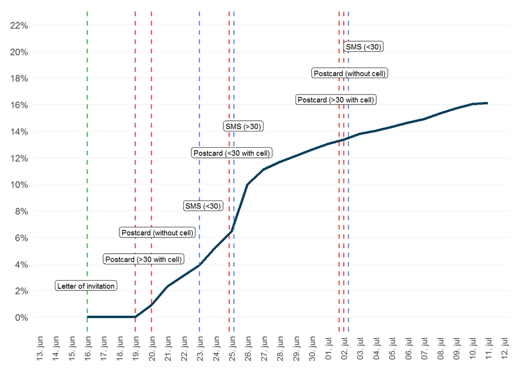

Figure 1 outlines both the gradual incline of the responses assumed created by the letter of invitation, and the responses created when the various SMS-reminders were distributed. The increase in number of responses generated by the SMS to invitees more than 30 years of age is notably steeper when compared to the SMS distributed to invitees less than 30 years.

### Responses by Existing Panel Members

The survey was distributed to 29 152 panel members on June 12th, 2025 for the soft launch and June 13th for the main launch. The invitation contained information on the Norwegian Citizen Panel, unique URLs for each panel member that led to the questionnaire, and unique access code which the panel members could use to log in to the survey by accessing a link on www.uib.no/medborger.

The invitation and second reminder were distributed by email. The first and third reminder was distributed via SMS or email, depending on whether the panel member had a registered mobile phone number. Prior to wave 33, 55.1 percent of the panel members were registered with a mobile phone number.

Table 3: Responses and response rate for panel members during data collection

| Event | Response | Cumulative responses | Response rate | Cumulative response rate |
| --- | --- | --- | --- | --- |
| Invitation (12th/13th of June) | 5 270 | 5 270 | 34.1 % | 34.1 % |
| First reminder - email (18th of June) | 441 | 5 711 | 2.9 % | 37 % |
| First reminder - SMS (18th of June) | 3 126 | 8 837 | 20.3 % | 57.3 % |
| Second reminder (25th of June) | 410 | 9 247 | 2.7 % | 60 % |
| Third reminder - email (2nd of July) | 457 | 9 704 | 3 % | 63 % |
| Third reminder - SMS (2nd of July) | 828 | 10 532 | 5.4 % | 68.4 % |

Using the same methodology as in previous waves to calculate response rates, respondents who have not participated in any of the last three waves are excluded. This leaves us with 15 432 eligible respondents. The overall response rate, as reported in table 3, is 68.4 %.

#### Response of Existing Panel Members Over Time

Comparing the number of wave 33 respondents (10 532) to the number of respondents in the previous wave 32 (10 617), gives an overall wave-to-wave retention rate of 99 percent. Figure 2 illustrates each wave of recruitment by individual lines, showing how many respondents are retained for each data collection wave. The NCP has conducted 34 waves of data collection. Depending on when respondents were recruited, the current wave is highlighted with a red circle. For respondents recruited in wave 1, the current wave is the 34th data collection (t34).

The wave-to-wave retention rate increases substantially after the first three waves (t1 - t3), stabilizing around a mean of 95 percent.

Figure 2: Wave-to-wave retention rate

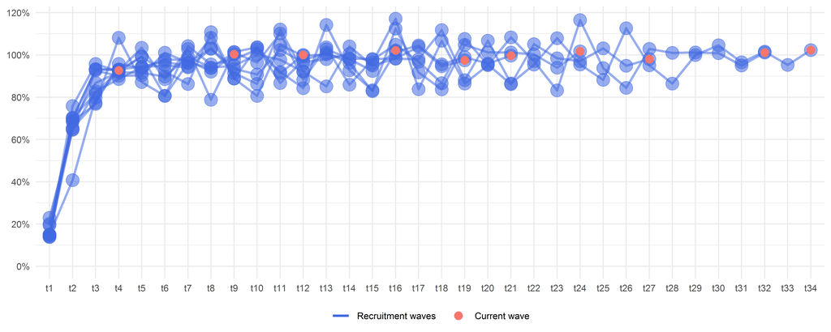

### Platforms

A set number of survey questions must be answered for a person to be included as a respondent. 9 percent of the mobile users did not reach this minimum requirement, compared to 37 percent for non-mobile users.

Mobile device usage is highest among respondents aged 18 to 45 years. As shown in Figure 3, the portion of mobile users declines with age.

Figure 3: Share of mobile users by gender and age

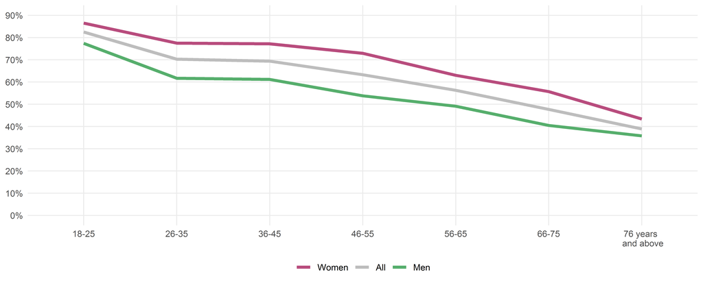

### Time Usage

The average respondent used 18.5 minutes to complete the questionnaire. Measuring average time usage is a challenge, as respondents may leave the questionnaire open in order to complete the survey later. This idle time causes an artificially high average for completing the survey. The average therefore includes only the respondents that spent 60 minutes or less completing the survey.

Figure 4: Time usage distribution of survey respondents

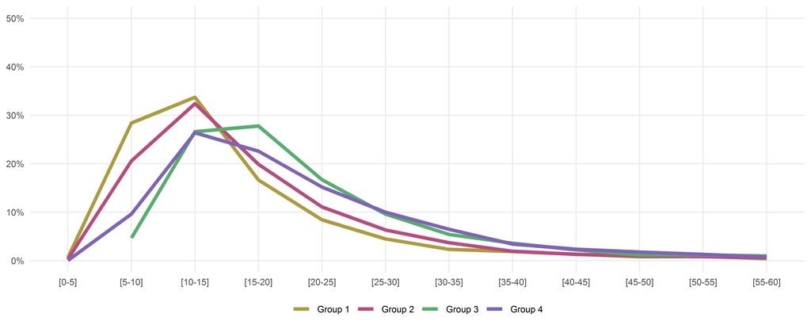

Table 4: Average time usage in minutes for each subset

| Type | All | Group 1 | Group 2 | Group 3 | Group 4 |
| --- | --- | --- | --- | --- | --- |
| All users | 18.5 | 15.5 | 17.1 | 20.7 | 20.6 |
| Non-mobile users | 19.9 | 16.7 | 18.4 | 21.9 | 22.9 |
| Mobile users | 17.5 | 14.6 | 16.0 | 19.8 | 19.4 |

## Representativity

In this section, we describe the representativity of the panel as a whole. First, we will discuss factors explaining representativity. Thereafter we apply demographic variables to present data on representativity by different strata. The data on representativity is the foundation for the section on weighting.

### Factors Explaining Representativity

There are two main points that can serve as explanations to non-response and lack of representativity when recruiting and maintaining panel members:

- access to and familiarity with the internet (given that a web-based questionnaire was the only response mode made available)
- the motivation and interest of the respondents

The first challenge is strongly related to the age composition of the survey respondents. Although Norway has a very high computer and internet density, the probability of having an e-mail address, and the skills required to access and fill in an online questionnaire, decreases with age. The second challenge, motivation and interest, is often explained by the respondents’ level of education. In addition to age and education, we added the variables of geography and gender in order to test the representativity of the survey respondents. The variables have the following categories:

- Age: 18-29 years, 30-59 years, 60 and above.
- Highest completed education: no education/elementary school, upper secondary, university/university college.
- Geography: Oslo, Eastern Norway, Southern Norway, Western Norway, Trøndelag, Northern Norway.

Please note that starting wave 21, the former county of Akershus is part of Eastern Norway, rather than being part of the traditional Akershus/Oslo stratum.

### Representativity of the Norwegian Citizen Panel

The sampling frame of the survey equals to the Norwegian population above the age of 18, comprising a population of approximately 4.4 million individuals. Earlier reports have documented a systematic underrepresentation of respondents belonging to the two lowest educational groups, independent of gender and age. The underrepresentation is particularly strong for young men. As expected, individuals with education from universities or university colleges are overrepresented. All of these observations hold true for wave 33.

Table 5: Age distribution in the population and the net sample

| Type | 18 - 29 years | 30 - 59 years | 60 years and above |
| --- | --- | --- | --- |
| Population | 17.9 % | 48.5 % | 33.7 % |
| Net sample | 10.5 % | 39 % | 50.5 % |

From the age distribution presented in table 5, we see that both the youngest age groups are underrepresented in the net sample of wave 33 when compared to the distribution we find in the population. Inversely, respondents age 60 years and more are overrepresented in the net sample when compared to the population.

Over time, and until wave 30, the panel exhibited a drift from perfect representativity with regard to age. As figure 5 shows, the oldest respondents started out underrepresented in wave 1, but have become increasingly overrepresented over time. The youngest respondents have become increasingly underrepresented at the same time. This has been explained by a difference in panel membership loyalty; younger panel members are less likely to participate in new waves of NCP after having been an active member of the panel. Recruitment in wave 30 introduced stratified sampling, and the youngest group was no longer underrepresented. Figure 5 shows a steep drop in representativity for the youngest age group from wave 30 to wave 31, highlighting how difficult it is to activate this age group. From wave 31 to wave 32, the drop off continues, but at a more docile rate. Wave 33 exhibits better representativity among younger people due to oversampling of this age group during recruitment, but less aggressive when compared to recruitment in wave 30.

Figure 5: Representativity of age groups

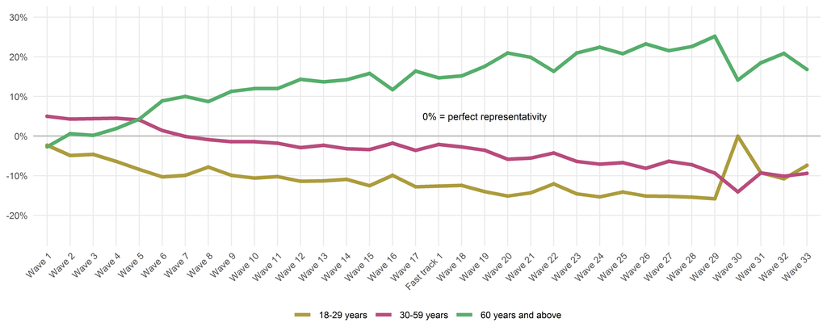

Table 6: Combined distribution of age and gender in the population and the net sample

| Type | 18 - 29 years Men | 18 - 29 years Women | 30 - 59 years Men | 30 - 59 years Women | 60 years and above Men | 60 years and above Women |
| --- | --- | --- | --- | --- | --- | --- |
| Population | 9.2 % | 8.7 % | 24.5 % | 24 % | 16.2 % | 17.4 % |
| Net sample | 4.6 % | 5.8 % | 19 % | 20 % | 26.9 % | 23.6 % |

The inclusion of educational level in table 7 reveals a systematic underrepresentation of respondents with little or no education, irrespective of age and gender. The underrepresentation is present in all age brackets, but is especially strong for young respondents.

Table 7: Combined distribution of age, gender and education in the population and the net sample

|  |  | Population Men | Population Women | Net sample Men | Net sample Women |
| --- | --- | --- | --- | --- | --- |
| 18 - 29 years | No education/elementary school | 4.1 % | 3.3 % | 0.5 % | 0.6 % |
|  | Upper secondary education | 3.5 % | 2.8 % | 2.6 % | 3 % |
|  | University/university college | 1.6 % | 2.6 % | 1.4 % | 2.1 % |
| 30 - 59 years | No education/elementary school | 4.7 % | 3.6 % | 0.5 % | 0.4 % |
|  | Upper secondary education | 10.2 % | 6.8 % | 5.8 % | 3.8 % |
|  | University/university college | 9.6 % | 13.5 % | 12.9 % | 15.8 % |
| 60 years and above | No education/elementary school | 3.4 % | 4.4 % | 1.6 % | 1.4 % |
|  | Upper secondary education | 8.1 % | 8 % | 9.3 % | 6.9 % |
|  | University/university college | 4.8 % | 5.1 % | 16.2 % | 15.4 % |

Respondents who have completed upper secondary education or have not completed any level of education are in general underrepresented, while respondents with university/university college as their highest level of education are overrepresented. Those who have university or university college education are overrepresented in the two oldest age brackets, irrespective of gender.

Figure 6: Representativity of education groups

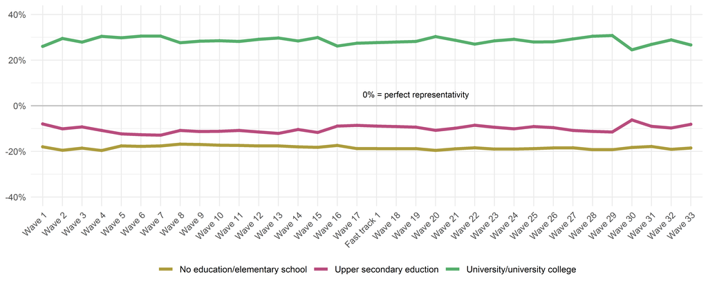

Figure 6 illustrates the representation of education groups from wave 1. The general trend is that the highly educated are overrepresented compared to those with less or no education. Except for slight improvements in representativity of the education groups when new respondents are recruited (wave 1, 3, 8, 11, 14, 16, 18, 22, 25, 30, 33), the overall pattern has remained stable throughout all waves.

Table 8: Combined distribution of age, gender and geography in the population and the net sample

|  |  | Population Men | Population Women | Population Total | Net sample Men | Net sample Women | Net sample Total |
| --- | --- | --- | --- | --- | --- | --- | --- |
| Oslo | 18-29 years | 1.2% | 1.3% | 2.5% | 0.8 % | 1 % | 1.8 % |
|  | 30-59 years | 3.6% | 3.5% | 7.1% | 3.3 % | 3.7 % | 7.1 % |
|  | 60 years and above | 1.5% | 1.7% | 3.2% | 3.1 % | 3.2 % | 6.3 % |
|  | Total | 6.3% | 6.5% | 12.8% | 7.2 % | 8 % | 15.2 % |
| Eastern Norway | 18-29 years | 3.3% | 3% | 6.3% | 1.5 % | 1.9 % | 3.4 % |
|  | 30-59 years | 9.1% | 9.1% | 18.2% | 6.2 % | 6.7 % | 12.9 % |
|  | 60 years and above | 6.6% | 7.2% | 13.8% | 10.7 % | 9.2 % | 19.9 % |
|  | Total | 19% | 19.3% | 38.3% | 18.5 % | 17.7 % | 36.2 % |
| Southern Norway | 18-29 years | 0.6% | 0.5% | 1.1% | 0.3 % | 0.3 % | 0.6 % |
|  | 30-59 years | 1.4% | 1.3% | 2.7% | 1 % | 1 % | 2 % |
|  | 60 years and above | 1% | 1% | 2% | 1.4 % | 1.3 % | 2.7 % |
|  | Total | 2.9% | 2.9% | 5.8% | 2.7 % | 2.6 % | 5.3 % |
| Western Norway | 18-29 years | 2.4% | 2.3% | 4.7% | 1.3 % | 1.6 % | 2.9 % |
|  | 30-59 years | 6.2% | 6% | 12.2% | 5.4 % | 5.3 % | 10.6 % |
|  | 60 years and above | 4.1% | 4.3% | 8.4% | 7.5 % | 6.2 % | 13.7 % |
|  | Total | 12.8% | 12.6% | 25.4% | 14.1 % | 13.1 % | 27.2 % |
| Trøndelag | 18-29 years | 0.9% | 0.8% | 1.7% | 0.4 % | 0.6 % | 1 % |
|  | 30-59 years | 2.1% | 2% | 4.1% | 1.7 % | 1.8 % | 3.5 % |
|  | 60 years and above | 1.4% | 1.5% | 3% | 2.2 % | 1.8 % | 4 % |
|  | Total | 4.4% | 4.4% | 8.8% | 4.3 % | 4.2 % | 8.5 % |
| Northern Norway | 18-29 years | 0.8% | 0.7% | 1.5% | 0.4 % | 0.4 % | 0.8 % |
|  | 30-59 years | 2.1% | 2% | 4.1% | 1.4 % | 1.6 % | 3 % |
|  | 60 years and above | 1.6% | 1.7% | 3.3% | 2.1 % | 1.8 % | 3.8 % |
|  | Total | 4.5% | 4.4% | 8.9% | 3.8 % | 3.8 % | 7.6 % |

Figure 7: Representativity of regions

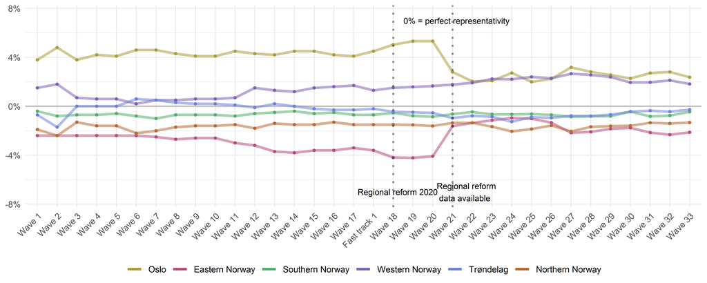

For wave 21, population data stratified on the new regions was available for the first time since the regional reform of 2020. While this data eliminates some small uncertainty in the representativity analyses[^5], it also introduces a break in time series for Oslo (previously including Akershus) and Eastern Norway (now including Akershus). In the 2024 regional reform, Akershus, among other former counties, were reinstituted as an independent county. In order to preserve the regional division established in 2020, Akershus remains a part of Eastern Norway in our analysis. Compared to age and education, geography does, however, not seem to be a strong determinant of survey participation. Apart from effects from the regional reform, the geographic representativity is more or less stable over time.

## Weighting

A weight has been calculated to compensate for observed biases. The weight is equal to the relation between a given strata in the population and the total population, divided by the relation between a given strata in the net sample and the total net sample[^6]. This procedure returns values around 1, and always more than 0. Respondents belonging to a stratum that is underrepresented will receive a weight above 1 and respondents belonging to an overrepresented stratum will receive a weight below 1. We have listed the weights of the different strata in the table in the appendix.

When calculating the weight, information regarding the respondents’ geographical location, gender, and age is based on registry data. Information on these variables was included in the sample file received from the Norwegian National Population Registry upon recruitment. Information on the level of education is collected from NCP surveys. 2 percent of the 33rd wave net sample have not answered the question about level of education.

- **Weight 4** combines demographic variables with education. Respondents with missing data on the education variable are only weighted on demography (the education component of the weight is in these cases set to 1). Level of education is recoded into 1) upper secondary and lower levels of education, and 2) university/university college. Weight values are capped to a minimum of 0.2 and a maximum of 5. Capping limits the influence of highly overrepresented and underrepresented strata on the weighted statistics, and reduces the likelihood of the weights being overfitted with respect to the demographic composition of each wave.

The following demographic variables are applied in weight4:

- **Age**: 18-29 years, 30-59 years, 60 and above.
- **Gender**: Male, female.
- **Highest level of completed education**: upper secondary and lower, university/university college.
- **Geography**: Oslo, Eastern Norway, Southern Norway, Western Norway, Trøndelag, Northern Norway.

When applied, the weight will provide a weighted N equal to the number of cases in the dataset. In other words, the weight is calculated using the whole dataset. NCP has an extensive use of (randomized) sub-groups, which might alter the demographic profile of the sub-group compared to the whole dataset.

Consequently, the weight might be less precise for some sub-groups. Note that the dataset is provided with necessary information[^7] to calculate custom weights if needed, following the procedure described above.

Table 9 shows the effects of weight 4 on the distribution of self-reported level of education in the net sample. As we can observe, the weight gives the sample a distribution closer to the population. It is important to stress that the unweighted distribution is not ideal, with a clear underrepresentation of people with lower levels of education, and young people.

Table 9: Effect of weight4 on self-reported level of education

|  | Sample - standard | Sample - weighted | Population | Difference between sample and population | Difference between weighted sample and population |
| --- | --- | --- | --- | --- | --- |
| Upper secondary school and lower | 36.3 % | 62.9 % | 62.9 % | -26.6 | 0 |
| University/university college | 63.7 % | 37.1 % | 37.1 % | 26.6 | 0 |

## Appendix

Table 10: Weight4 applied to different strata

|  | Age | Education | Men | Women |  | Age | Education | Men | Women |
| --- | --- | --- | --- | --- | --- | --- | --- | --- | --- |
| Oslo | 18-29 | Upper secondary and lower | 2.5 | 1.4 | Western Norway | 18-29 | Upper secondary and lower | 2.4 | 1.5 |
|  |  | University/university college | 1 | 1.3 |  |  | University/university college | 1 | 1.4 |
|  | 30-59 | Upper secondary and lower | 3.2 | 2.7 |  | 30-59 | Upper secondary and lower | 2 | 2.3 |
|  |  | University/university college | 0.7 | 0.7 |  |  | University/university college | 0.7 | 0.8 |
|  | 60+ | Upper secondary and lower | 1.1 | 1.2 |  | 60+ | Upper secondary and lower | 0.9 | 1.3 |
|  |  | University/university college | 0.3 | 0.3 |  |  | University/university college | 0.3 | 0.3 |
| Eastern Norway | 18-29 | Upper secondary and lower | 2.4 | 1.9 | Trøndelag | 18-29 | Upper secondary and lower | 2.8 | 1.7 |
|  |  | University/university college | 1.5 | 1.2 |  |  | University/university college | 1.4 | 1 |
|  | 30-59 | Upper secondary and lower | 2.7 | 2.7 |  | 30-59 | Upper secondary and lower | 2.1 | 3.1 |
|  |  | University/university college | 0.8 | 1 |  |  | University/university college | 0.7 | 0.8 |
|  | 60+ | Upper secondary and lower | 1.1 | 1.5 |  | 60+ | Upper secondary and lower | 1.1 | 1.8 |
|  |  | University/university college | 0.3 | 0.3 |  |  | University/university college | 0.3 | 0.3 |
| Southern Norway | 18-29 | Upper secondary and lower | 2.2 | 1.6 | Northern Norway | 18-29 | Upper secondary and lower | 2.8 | 2.6 |
|  |  | University/university college | 1.1 | 1.4 |  |  | University/university college | 0.9 | 1.2 |
|  | 30-59 | Upper secondary and lower | 1.9 | 2 |  | 30-59 | Upper secondary and lower | 2.6 | 2.1 |
|  |  | University/university college | 0.8 | 1.1 |  |  | University/university college | 0.8 | 0.9 |
|  | 60+ | Upper secondary and lower | 1.4 | 1.6 |  | 60+ | Upper secondary and lower | 1.3 | 2 |
|  |  | University/university college | 0.3 | 0.3 |  |  | University/university college | 0.3 | 0.4 |

[^1]: Some examples: sorting respondents in different thematic subsets, randomly allocate treatment value in experiments, randomize order of an answer list/array, order a sequence of questions by random, ask a given question to a subset of the respondents.
[^2]: Please see following resource: https://developer.mozilla.org/en-US/docs/Web/JavaScript/Reference/Global_Objects/Math/random
[^3]: Please see following resource: https://developer.mozilla.org/en-US/docs/Web/JavaScript/Reference/Global_Objects/Math/floor
[^4]: Collected from Mike Bostocks visualisation: https://bost.ocks.org/mike/shuffle/
[^5]: Note that Oslo (including Akershus), and Eastern Norway diverge in wave 18, due to the regional reform implemented 1st of January 2020.
[^6]: The applied formula for weight wi for element i, in strata h is: $w_i=\frac{N_h/N}{n_h/n}$
[^7]: See columns r33_Weight4_stratapop and r33_generic_stratapop